# Copia de Act2_Sergio Segura Gomez

## Paso 1: Importando las librerías necesarias

Lo primero es cargar todas las herramientas que vamos a usar a lo largo del notebook.

```python
import numpy as np        # Operaciones numéricas eficientes
import pandas as pd       # Manejo de datos en tablas (DataFrames)

import matplotlib.pyplot as plt   # Visualizaciones básicas
import seaborn as sns             # Visualizaciones estadísticas más elaboradas

from sklearn.preprocessing import StandardScaler      # Para normalizar la escala de los datos
from sklearn.model_selection import train_test_split  # Para dividir datos en entrenamiento y prueba

from sklearn.svm import SVC  # El modelo de clasificación SVM

from sklearn.metrics import accuracy_score, confusion_matrix, classification_report
# accuracy_score    → fracción de predicciones correctas
# confusion_matrix  → detalle de aciertos y errores por clase
# classification_report → precisión, recall y F1-score por clase
```

## Paso 2: Cargando el dataset

El archivo CSV está almacenado en Google Drive. Lo montamos y lo cargamos con pandas.

```python
# Montamos Google Drive para poder acceder al archivo CSV
from google.colab import drive
drive.mount('/content/drive')

resources_path = '/content/drive/My Drive'
data = pd.read_csv(resources_path+'/resources/train.csv')
data
```

|  | battery_power | blue | clock_speed | dual_sim | fc | four_g | int_memory | m_dep | mobile_wt | n_cores | ... | px_height | px_width | ram | sc_h | sc_w | talk_time | three_g | touch_screen | wifi | price_range |
| --- | --- | --- | --- | --- | --- | --- | --- | --- | --- | --- | --- | --- | --- | --- | --- | --- | --- | --- | --- | --- | --- |
| 0 | 842 | 0 | 2.2 | 0 | 1 | 0 | 7 | 0.6 | 188 | 2 | ... | 20 | 756 | 2549 | 9 | 7 | 19 | 0 | 0 | 1 | 1 |
| 1 | 1021 | 1 | 0.5 | 1 | 0 | 1 | 53 | 0.7 | 136 | 3 | ... | 905 | 1988 | 2631 | 17 | 3 | 7 | 1 | 1 | 0 | 2 |
| 2 | 563 | 1 | 0.5 | 1 | 2 | 1 | 41 | 0.9 | 145 | 5 | ... | 1263 | 1716 | 2603 | 11 | 2 | 9 | 1 | 1 | 0 | 2 |
| 3 | 615 | 1 | 2.5 | 0 | 0 | 0 | 10 | 0.8 | 131 | 6 | ... | 1216 | 1786 | 2769 | 16 | 8 | 11 | 1 | 0 | 0 | 2 |
| 4 | 1821 | 1 | 1.2 | 0 | 13 | 1 | 44 | 0.6 | 141 | 2 | ... | 1208 | 1212 | 1411 | 8 | 2 | 15 | 1 | 1 | 0 | 1 |
| ... | ... | ... | ... | ... | ... | ... | ... | ... | ... | ... | ... | ... | ... | ... | ... | ... | ... | ... | ... | ... | ... |
| 1995 | 794 | 1 | 0.5 | 1 | 0 | 1 | 2 | 0.8 | 106 | 6 | ... | 1222 | 1890 | 668 | 13 | 4 | 19 | 1 | 1 | 0 | 0 |
| 1996 | 1965 | 1 | 2.6 | 1 | 0 | 0 | 39 | 0.2 | 187 | 4 | ... | 915 | 1965 | 2032 | 11 | 10 | 16 | 1 | 1 | 1 | 2 |
| 1997 | 1911 | 0 | 0.9 | 1 | 1 | 1 | 36 | 0.7 | 108 | 8 | ... | 868 | 1632 | 3057 | 9 | 1 | 5 | 1 | 1 | 0 | 3 |
| 1998 | 1512 | 0 | 0.9 | 0 | 4 | 1 | 46 | 0.1 | 145 | 5 | ... | 336 | 670 | 869 | 18 | 10 | 19 | 1 | 1 | 1 | 0 |
| 1999 | 510 | 1 | 2.0 | 1 | 5 | 1 | 45 | 0.9 | 168 | 6 | ... | 483 | 754 | 3919 | 19 | 4 | 2 | 1 | 1 | 1 | 3 |

2000 rows × 21 columns

## Paso 3: Análisis Exploratorio de los Datos (EDA)

Antes de entrenar cualquier modelo, es fundamental **entender los datos**. En esta sección exploraremos el dataset para conocer su estructura, distribuciones y relaciones entre variables.

> Un buen EDA puede ahorrarte horas de depuración más adelante. ¡No te lo saltes!

```python
# ¿Cuántas filas y columnas tiene el dataset?
data.shape
```

```
(2000, 21)
```

```python
# Tipos de datos por columna y conteo de valores nulos
# Si hay columnas con valores nulos, habría que tratarlas antes de entrenar
data.info()
```

```
<class 'pandas.core.frame.DataFrame'>
RangeIndex: 2000 entries, 0 to 1999
Data columns (total 21 columns):
 #   Column         Non-Null Count  Dtype
---  ------         --------------  -----
 0   battery_power  2000 non-null   int64
 1   blue           2000 non-null   int64
 2   clock_speed    2000 non-null   float64
 3   dual_sim       2000 non-null   int64
 4   fc             2000 non-null   int64
 5   four_g         2000 non-null   int64
 6   int_memory     2000 non-null   int64
 7   m_dep          2000 non-null   float64
 8   mobile_wt      2000 non-null   int64
 9   n_cores        2000 non-null   int64
 10  pc             2000 non-null   int64
 11  px_height      2000 non-null   int64
 12  px_width       2000 non-null   int64
 13  ram            2000 non-null   int64
 14  sc_h           2000 non-null   int64
 15  sc_w           2000 non-null   int64
 16  talk_time      2000 non-null   int64
 17  three_g        2000 non-null   int64
 18  touch_screen   2000 non-null   int64
 19  wifi           2000 non-null   int64
 20  price_range    2000 non-null   int64
dtypes: float64(2), int64(19)
memory usage: 328.3 KB
```

### Estadísticas descriptivas

¿Cómo se distribuyen los valores de cada variable? El siguiente resumen nos da la media, desviación estándar, mínimos y máximos de cada columna. Es muy útil para detectar valores atípicos o escalas muy dispares entre variables.

```python
# Resumen estadístico: media, desviación estándar, percentiles de cada variable
# Fíjate en las diferencias de escala entre columnas (ej: ram vs blue)
data.describe()
```

|  | battery_power | blue | clock_speed | dual_sim | fc | four_g | int_memory | m_dep | mobile_wt | n_cores | ... | px_height | px_width | ram | sc_h | sc_w | talk_time | three_g | touch_screen | wifi | price_range |
| --- | --- | --- | --- | --- | --- | --- | --- | --- | --- | --- | --- | --- | --- | --- | --- | --- | --- | --- | --- | --- | --- |
| count | 2000.000000 | 2000.0000 | 2000.000000 | 2000.000000 | 2000.000000 | 2000.000000 | 2000.000000 | 2000.000000 | 2000.000000 | 2000.000000 | ... | 2000.000000 | 2000.000000 | 2000.000000 | 2000.000000 | 2000.000000 | 2000.000000 | 2000.000000 | 2000.000000 | 2000.000000 | 2000.000000 |
| mean | 1238.518500 | 0.4950 | 1.522250 | 0.509500 | 4.309500 | 0.521500 | 32.046500 | 0.501750 | 140.249000 | 4.520500 | ... | 645.108000 | 1251.515500 | 2124.213000 | 12.306500 | 5.767000 | 11.011000 | 0.761500 | 0.503000 | 0.507000 | 1.500000 |
| std | 439.418206 | 0.5001 | 0.816004 | 0.500035 | 4.341444 | 0.499662 | 18.145715 | 0.288416 | 35.399655 | 2.287837 | ... | 443.780811 | 432.199447 | 1084.732044 | 4.213245 | 4.356398 | 5.463955 | 0.426273 | 0.500116 | 0.500076 | 1.118314 |
| min | 501.000000 | 0.0000 | 0.500000 | 0.000000 | 0.000000 | 0.000000 | 2.000000 | 0.100000 | 80.000000 | 1.000000 | ... | 0.000000 | 500.000000 | 256.000000 | 5.000000 | 0.000000 | 2.000000 | 0.000000 | 0.000000 | 0.000000 | 0.000000 |
| 25% | 851.750000 | 0.0000 | 0.700000 | 0.000000 | 1.000000 | 0.000000 | 16.000000 | 0.200000 | 109.000000 | 3.000000 | ... | 282.750000 | 874.750000 | 1207.500000 | 9.000000 | 2.000000 | 6.000000 | 1.000000 | 0.000000 | 0.000000 | 0.750000 |
| 50% | 1226.000000 | 0.0000 | 1.500000 | 1.000000 | 3.000000 | 1.000000 | 32.000000 | 0.500000 | 141.000000 | 4.000000 | ... | 564.000000 | 1247.000000 | 2146.500000 | 12.000000 | 5.000000 | 11.000000 | 1.000000 | 1.000000 | 1.000000 | 1.500000 |
| 75% | 1615.250000 | 1.0000 | 2.200000 | 1.000000 | 7.000000 | 1.000000 | 48.000000 | 0.800000 | 170.000000 | 7.000000 | ... | 947.250000 | 1633.000000 | 3064.500000 | 16.000000 | 9.000000 | 16.000000 | 1.000000 | 1.000000 | 1.000000 | 2.250000 |
| max | 1998.000000 | 1.0000 | 3.000000 | 1.000000 | 19.000000 | 1.000000 | 64.000000 | 1.000000 | 200.000000 | 8.000000 | ... | 1960.000000 | 1998.000000 | 3998.000000 | 19.000000 | 18.000000 | 20.000000 | 1.000000 | 1.000000 | 1.000000 | 3.000000 |

8 rows × 21 columns

### Matriz de correlación

La matriz de correlación nos muestra qué tan relacionadas están las variables entre sí. Un valor cercano a **1 o -1** indica una correlación fuerte; cercano a **0** indica poca o ninguna relación lineal.

Esto también nos ayuda a identificar si alguna variable tiene una relación directa con `price_range`.

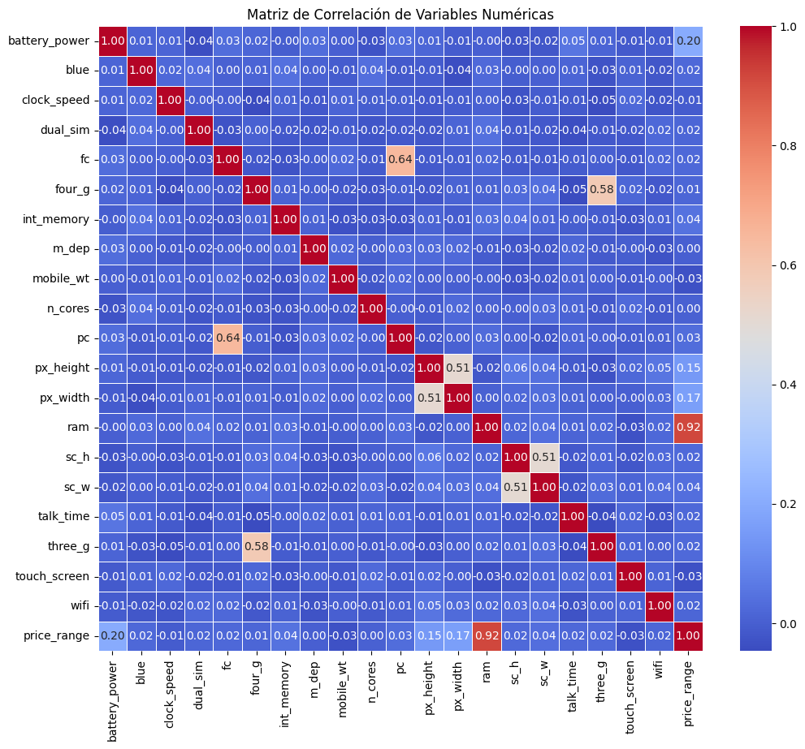

```python
# Calculamos la correlación entre todas las variables numéricas del dataset
correlation_matrix = data.corr()

plt.figure(figsize=(12, 10))
sns.heatmap(correlation_matrix, annot=True, cmap='coolwarm', fmt=".2f", linewidths=0.5)
plt.title("Matriz de Correlación de Variables Numéricas")
plt.show()
```

### Distribución de variables categóricas

Varias variables son binarias (0 o 1). Vamos a graficar cuántos registros tienen cada valor para detectar posibles desequilibrios en los datos.

```
       battery_power       blue  clock_speed     dual_sim           fc  \
count    2000.000000  2000.0000  2000.000000  2000.000000  2000.000000
mean     1238.518500     0.4950     1.522250     0.509500     4.309500
std       439.418206     0.5001     0.816004     0.500035     4.341444
min       501.000000     0.0000     0.500000     0.000000     0.000000
25%       851.750000     0.0000     0.700000     0.000000     1.000000
50%      1226.000000     0.0000     1.500000     1.000000     3.000000
75%      1615.250000     1.0000     2.200000     1.000000     7.000000
max      1998.000000     1.0000     3.000000     1.000000    19.000000

            four_g   int_memory        m_dep    mobile_wt      n_cores  ...  \
count  2000.000000  2000.000000  2000.000000  2000.000000  2000.000000  ...
mean      0.521500    32.046500     0.501750   140.249000     4.520500  ...
std       0.499662    18.145715     0.288416    35.399655     2.287837  ...
min       0.000000     2.000000     0.100000    80.000000     1.000000  ...
25%       0.000000    16.000000     0.200000   109.000000     3.000000  ...
50%       1.000000    32.000000     0.500000   141.000000     4.000000  ...
75%       1.000000    48.000000     0.800000   170.000000     7.000000  ...
max       1.000000    64.000000     1.000000   200.000000     8.000000  ...

         px_height     px_width          ram         sc_h         sc_w  \
count  2000.000000  2000.000000  2000.000000  2000.000000  2000.000000
mean    645.108000  1251.515500  2124.213000    12.306500     5.767000
std     443.780811   432.199447  1084.732044     4.213245     4.356398
min       0.000000   500.000000   256.000000     5.000000     0.000000
25%     282.750000   874.750000  1207.500000     9.000000     2.000000
50%     564.000000  1247.000000  2146.500000    12.000000     5.000000
75%     947.250000  1633.000000  3064.500000    16.000000     9.000000
max    1960.000000  1998.000000  3998.000000    19.000000    18.000000

         talk_time      three_g  touch_screen         wifi  price_range
count  2000.000000  2000.000000   2000.000000  2000.000000  2000.000000
mean     11.011000     0.761500      0.503000     0.507000     1.500000
std       5.463955     0.426273      0.500116     0.500076     1.118314
min       2.000000     0.000000      0.000000     0.000000     0.000000
25%       6.000000     1.000000      0.000000     0.000000     0.750000
50%      11.000000     1.000000      1.000000     1.000000     1.500000
75%      16.000000     1.000000      1.000000     1.000000     2.250000
max      20.000000     1.000000      1.000000     1.000000     3.000000

[8 rows x 21 columns]
```

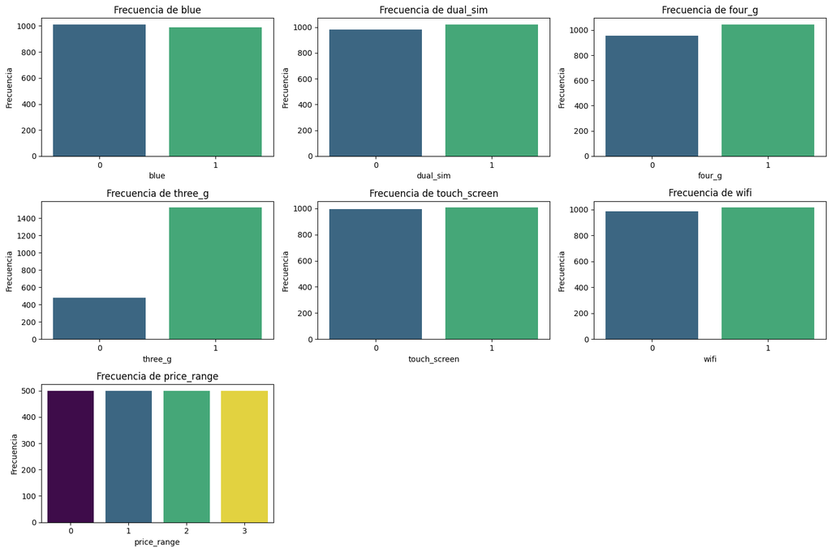

```python
df_info = data.describe()
print(df_info)

# Graficamos la frecuencia de cada valor en las variables categóricas (binarias)
# Un desequilibrio fuerte (ej: 95% ceros) podría afectar al modelo
categorical_vars = ['blue', 'dual_sim', 'four_g', 'three_g', 'touch_screen', 'wifi', 'price_range']
plt.figure(figsize=(15, 10))

for i, var in enumerate(categorical_vars, 1):
    plt.subplot(3, 3, i)
    sns.countplot(x=data[var], hue=data[var], palette="viridis", legend=False)
    plt.title(f"Frecuencia de {var}")
    plt.xlabel(var)
    plt.ylabel("Frecuencia")

plt.tight_layout()
plt.show()
```

### ¿Está balanceado el dataset?

Un dataset desbalanceado puede llevar a modelos sesgados. Por ejemplo, si el 90% de los datos pertenece a una sola clase, el modelo podría predecir siempre esa clase y tener 90% de exactitud... ¡sin aprender nada útil!

Vamos a revisar si las 4 clases de `price_range` están bien distribuidas.

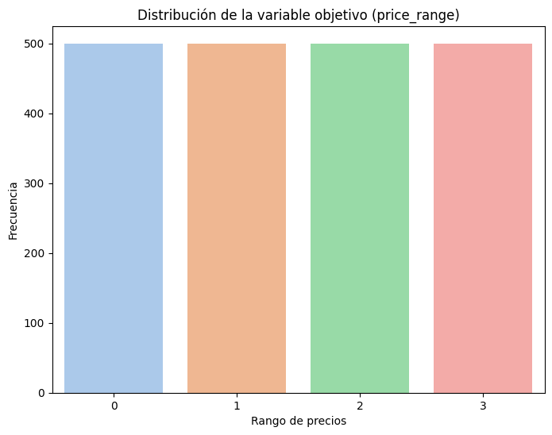

```
Distribución de price_range en porcentaje:
price_range
1    25.0
2    25.0
3    25.0
0    25.0
Name: proportion, dtype: float64
```

```python
# Visualizamos la distribución de la variable objetivo
plt.figure(figsize=(8, 6))
sns.countplot(x=data["price_range"], hue=data["price_range"], legend=False, palette="pastel")
plt.title("Distribución de la variable objetivo (price_range)")
plt.xlabel("Rango de precios")
plt.ylabel("Frecuencia")
plt.show()

# Calculamos el porcentaje de registros por clase
distribution = data["price_range"].value_counts(normalize=True) * 100

print("Distribución de price_range en porcentaje:")
print(distribution)
```

**¡Perfecto!** El dataset está perfectamente balanceado: cada rango de precio representa aproximadamente el 25% de los datos. Esto significa que la exactitud (*accuracy*) es una métrica confiable para evaluar el modelo.

## Paso 5: Entrenamiento del modelo SVM

¡Llegó el momento de entrenar! El proceso tiene tres etapas:

1. **Dividir** los datos en entrenamiento y prueba
2. **Escalar** las variables para que todas tengan el mismo peso
3. **Entrenar** el SVM con los datos de entrenamiento escalados

```python
# Separamos las características (X) de la variable objetivo (y)
X = data.drop(columns='price_range')
y = data['price_range']

# Dividimos en 80% para entrenamiento y 20% para evaluación final
# random_state=123 garantiza reproducibilidad: siempre obtendremos la misma división
X_train, X_test, y_train, y_test = train_test_split(
    X,
    y,
    train_size=0.8,
    random_state=123,
    shuffle=True
)

print(f"Datos de entrenamiento: {X_train.shape[0]} filas")
print(f"Datos de prueba:        {X_test.shape[0]} filas")
```

```
Datos de entrenamiento: 1600 filas
Datos de prueba:        400 filas
```

### Escalado de los atributos

El SVM es muy sensible a la escala de los datos. Variables como `ram` (valores en miles de MB) pueden dominar sobre variables como `blue` (0 o 1), dándoles más peso del que merecen.

Con `StandardScaler` transformamos cada variable para que tenga **media = 0** y **desviación estándar = 1**.

> **Importante:** ajustamos el escalador (`fit`) **solo con los datos de entrenamiento** y luego lo aplicamos (`transform`) tanto al train como al test. Esto evita el *data leakage*: que información del conjunto de prueba "filtre" al modelo durante el entrenamiento.

```python
scaler = StandardScaler()

# fit_transform: aprende la media y desviación estándar DEL TRAIN y escala
X_train_scaled = scaler.fit_transform(X_train)

# transform: aplica la misma escala (aprendida del train) al test
# Nunca usamos fit sobre el test para evitar data leakage
X_test_scaled = scaler.transform(X_test)
```

```python
# Creamos el modelo SVM con kernel lineal
# kernel="linear" → busca un hiperplano lineal para separar las clases
# C=1 → parámetro de regularización: valores más altos permiten menos errores
#        pero pueden sobreajustar; valores más bajos generalizan mejor
modeloSVM = SVC(kernel="linear", C=1, random_state=1234)

# Entrenamos con los datos escalados de entrenamiento
# El modelo aprende los patrones que separan las 4 clases de precio
modeloSVM.fit(X_train_scaled, y_train)

modeloSVM
```

```
SVC(C=1, kernel='linear', random_state=1234)
```

```python
# Le pedimos al modelo que prediga el rango de precio para los datos de prueba
# El modelo nunca ha "visto" estos datos durante el entrenamiento
predictSVM = modeloSVM.predict(X_test_scaled)
predictSVM
```

```
array([1, 3, 3, 0, 3, 3, 1, 0, 0, 1, 0, 1, 3, 1, 1, 3, 0, 3, 2, 1, 1, 0,
       0, 3, 2, 2, 3, 2, 2, 1, 0, 1, 0, 1, 2, 3, 1, 2, 1, 1, 2, 3, 2, 1,
       1, 0, 0, 2, 2, 0, 3, 1, 2, 1, 0, 2, 0, 0, 2, 3, 1, 0, 2, 1, 2, 2,
       0, 2, 3, 1, 3, 1, 0, 2, 0, 2, 0, 1, 1, 0, 0, 0, 3, 2, 2, 1, 2, 0,
       0, 2, 2, 2, 1, 2, 3, 0, 0, 1, 0, 3, 2, 1, 3, 3, 1, 1, 3, 2, 3, 3,
       2, 2, 3, 2, 3, 3, 3, 0, 1, 3, 2, 2, 3, 0, 1, 1, 3, 2, 2, 1, 3, 0,
       3, 1, 0, 2, 2, 3, 1, 3, 2, 2, 3, 1, 3, 2, 2, 0, 0, 1, 1, 3, 2, 0,
       3, 3, 3, 0, 0, 0, 2, 0, 1, 3, 1, 1, 0, 1, 1, 0, 1, 2, 1, 1, 2, 0,
       2, 0, 2, 2, 2, 3, 1, 0, 3, 3, 0, 1, 1, 2, 2, 1, 2, 3, 0, 3, 1, 2,
       3, 1, 1, 1, 0, 3, 2, 3, 1, 3, 3, 2, 3, 2, 3, 1, 1, 0, 0, 1, 2, 1,
       0, 1, 1, 2, 2, 0, 3, 1, 2, 1, 0, 3, 3, 2, 1, 2, 2, 2, 1, 0, 0, 2,
       3, 2, 2, 1, 1, 3, 2, 3, 0, 1, 2, 2, 0, 2, 3, 0, 3, 0, 3, 0, 2, 0,
       2, 2, 2, 1, 3, 1, 0, 0, 1, 0, 3, 1, 2, 2, 3, 3, 3, 2, 3, 3, 1, 1,
       1, 2, 2, 3, 2, 2, 3, 3, 1, 2, 2, 1, 2, 1, 1, 1, 3, 2, 2, 2, 3, 0,
       2, 3, 0, 0, 1, 2, 2, 3, 3, 0, 3, 2, 2, 0, 3, 3, 2, 1, 2, 1, 3, 0,
       2, 2, 3, 1, 0, 1, 3, 2, 0, 0, 3, 1, 0, 3, 2, 1, 3, 3, 0, 2, 0, 3,
       3, 0, 2, 2, 2, 3, 0, 0, 3, 2, 1, 2, 3, 3, 2, 1, 2, 0, 0, 2, 3, 0,
       1, 2, 3, 1, 3, 2, 1, 0, 1, 2, 2, 1, 0, 0, 1, 0, 0, 1, 3, 3, 2, 2,
       2, 1, 0, 0])
```

## Paso 6: Evaluando el rendimiento del modelo

La exactitud sola no siempre cuenta toda la historia. Vamos a usar tres herramientas de evaluación para tener una visión completa:

- **Accuracy**: el porcentaje total de aciertos
- **Matriz de confusión**: nos muestra dónde se equivoca el modelo y con qué clases las confunde
- **Classification report**: precisión, recall y F1-score por cada clase de precio

```python
# La exactitud (accuracy) indica qué fracción de las predicciones fueron correctas
# Ejemplo: 0.95 significa que el modelo acertó en el 95% de los casos
accuracy_svm = accuracy_score(y_test, predictSVM)
print(f"Exactitud del modelo SVM: {accuracy_svm:.2%}")
```

```
Exactitud del modelo SVM: 95.25%
```

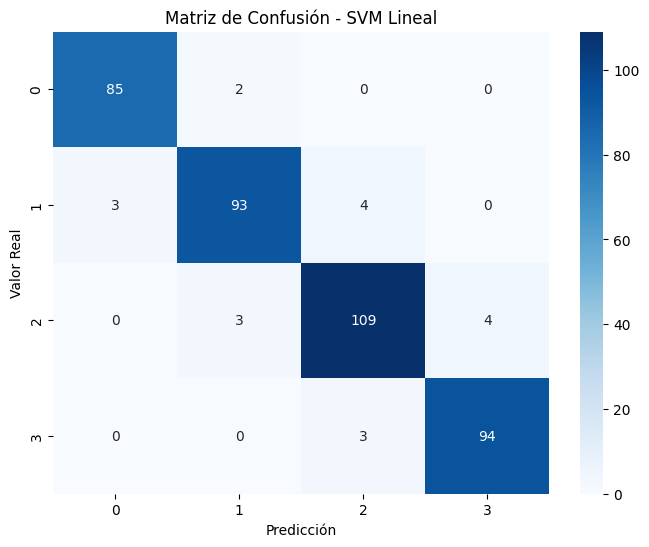

```
Reporte de Clasificación:
              precision    recall  f1-score   support

           0       0.97      0.98      0.97        87
           1       0.95      0.93      0.94       100
           2       0.94      0.94      0.94       116
           3       0.96      0.97      0.96        97

    accuracy                           0.95       400
   macro avg       0.95      0.95      0.95       400
weighted avg       0.95      0.95      0.95       400
```

```python
# La matriz de confusión muestra, por cada clase real (filas),
# cuántas veces el modelo predijo cada clase (columnas).
# La diagonal principal son los aciertos; el resto son errores.
cm = confusion_matrix(y_test, predictSVM)
plt.figure(figsize=(8, 6))
sns.heatmap(cm, annot=True, fmt='d', cmap='Blues',
            xticklabels=[0, 1, 2, 3], yticklabels=[0, 1, 2, 3])
plt.title("Matriz de Confusión - SVM Lineal")
plt.xlabel("Predicción")
plt.ylabel("Valor Real")
plt.show()

# El reporte de clasificación desglosa el rendimiento por clase:
# - Precisión:  de todo lo que predije como clase X, ¿cuánto era realmente X?
# - Recall:     de todo lo que era clase X, ¿cuánto logré identificar?
# - F1-score:   media armónica entre precisión y recall (equilibrio entre ambas)
print("Reporte de Clasificación:")
print(classification_report(y_test, predictSVM))
```

## Conclusiones

¡Llegamos al final! Repasemos lo que construimos y aprendimos:

- Seguimos un pipeline completo de Machine Learning: exploración de datos → preprocesamiento → entrenamiento → evaluación.
- Usamos **SVM con kernel lineal**, que logró una exactitud superior al 95% — un resultado excelente para un modelo sin ajuste de hiperparámetros.
- Aplicamos **escalado correcto**: ajustando el `StandardScaler` solo con los datos de entrenamiento para evitar *data leakage*.
- Evaluamos el modelo más allá de la exactitud, usando la **matriz de confusión** y el **classification report** para entender el comportamiento por clase.

### ¿Qué sigue?

En el próximo artículo exploraremos cómo llevar este modelo al siguiente nivel:

- **Validación cruzada** (*cross-validation*): evaluar el modelo en múltiples particiones para una estimación más robusta y confiable.
- **Búsqueda de hiperparámetros** (*GridSearchCV / RandomizedSearchCV*): encontrar automáticamente los mejores valores de `C`, `kernel` y otros parámetros del SVM.

Estos pasos son más costosos en cómputo, pero pueden marcar una diferencia importante en el rendimiento final. ¡Hasta la próxima!